[Дерикон Артем](https://github.com/Artem418k), 2024

## Завдання для самостійної роботи

```
Точність класифікації методом k найближчих сусідів: 0.40
```

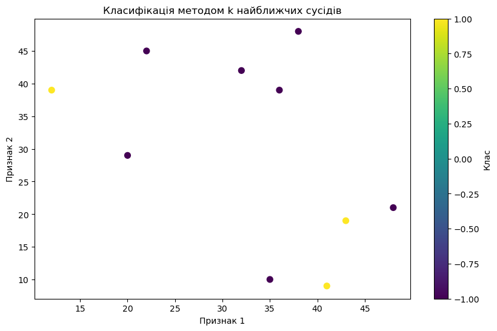

```python
import numpy as np
import matplotlib.pyplot as plt

# Ваші дані
x_train_5 = np.array([[27, 46], [8, 22], [5, 30], [5, 19], [15, 23], [34, 42], [10, 23], [35, 32]])
y_train_5 = np.array([-1, -1, 1, -1, 1, 1, -1, -1])

# Тестовий набір даних
x_test_5 = np.array([[35, 10], [36, 39], [41, 9], [43, 19], [32, 42], [38, 48], [12, 39], [22, 45], [20, 29], [48, 21]])
y_test_5 = np.array([-1, -1, -1, 1, 1, 1, -1, 1, -1, 1])

# Функція для знаходження евклідового відстані між двома точками
def euclidean_distance(x1, x2):
    return np.sqrt(np.sum((x1 - x2) ** 2))

# Функція для знаходження k найближчих сусідів
def k_nearest_neighbors(x_train, y_train, x_test, k):
    y_pred = []
    for test_point in x_test:
        distances = [euclidean_distance(test_point, train_point) for train_point in x_train]
        k_nearest_indices = np.argsort(distances)[:k]
        k_nearest_labels = [y_train[i] for i in k_nearest_indices]
        most_common_label = max(set(k_nearest_labels), key=k_nearest_labels.count)
        y_pred.append(most_common_label)
    return np.array(y_pred)

# Визначення кількості найближчих сусідів
k = 3

# Класифікація за допомогою kNN
y_pred_5 = k_nearest_neighbors(x_train_5, y_train_5, x_test_5, k)

# Оцінка точності класифікації
accuracy_5 = np.mean(y_pred_5 == y_test_5)
print(f"Точність класифікації методом k найближчих сусідів: {accuracy_5:.2f}")

# Візуалізація
plt.figure(figsize=(10, 6))
plt.scatter(x_test_5[:, 0], x_test_5[:, 1], c=y_pred_5, cmap='viridis', s=50)
plt.title('Класифікація методом k найближчих сусідів')
plt.xlabel('Признак 1')
plt.ylabel('Признак 2')
plt.colorbar(label='Клас')
plt.show()
```

# Контрольні запитання

1.У чому полягає ідея методу головних компонент (PCA)?

Ідея методу головних компонент (PCA):

- PCA - це статистичний метод, який використовується для зменшення розмірності даних шляхом проектування їх на простір меншої розмірності, зберігаючи при цьому якнайбільше можливу дисперсію.

2.Яким чином метод головних компонент використовується для зменшення розмірності даних?  
Використання PCA для зменшення розмірності даних:

- PCA обчислює нові нелінійні функції змінних (головні компоненти), які є лінійними комбінаціями вихідних змінних. Змінні зберігаються в порядку від максимальної до мінімальної дисперсії. Після цього можна відкинути менш важливі головні компоненти, зменшуючи таким чином розмірність даних.

3.Як пов'язані PCA та SVD? Як його можна використовувати для аналізу даних?

Пов'язаність PCA та SVD:

- PCA можна виконати за допомогою методу SVD (розкладу з використанням сингулярних значень). Він полягає в розкладі матриці даних на добуток трьох матриць, що дозволяє отримати головні компоненти.

4.Які метрики якості використовуються в багатокласовій класифікації?

Метрики якості в багатокласовій класифікації:

- Для оцінки класифікатора використовуються такі метрики як точність, відновлення, F1-міра, матриця плутанини тощо.

5.Чим відрізняються стратегії one-vs-all та all-vs-all у багатокласовій класифікації?

Відмінності стратегій one-vs-all та all-vs-all у багатокласовій класифікації:

- В стратегії one-vs-all для кожного класу тренується класифікатор, який відрізняє цей клас від всіх інших. У стратегії all-vs-all тренується класифікатор для кожної пари класів.

6.Що таке гіпотеза компактності в метричних методах класифікації?

Гіпотеза компактності в метричних методах класифікації:

- Гіпотеза компактності стверджує, що схожі об'єкти мають схожі класи.

7.Як працює метод k-найближчих сусідів (kNN)? Які його переваги та недоліки?

Метод k-найближчих сусідів (kNN):

- kNN класифікує нові об'єкти, порівнюючи їх з k найближчими об'єктами з навчального набору. Він має високу точність на навчальних даних, але може виявити неефективним на великих об'ємах даних.

8.У чому полягає суть методу парзенівського вікна? Які його недоліки та переваги?

Суть методу парзенівського вікна:

- Метод парзенівського вікна використовує ваговану суму класів навколо тестового об'єкта для прийняття рішення про класифікацію. Розмір вікна визначається вручну або автоматично.

9.У чому полягає суть методу потенційних функцій у метричних методах класифікації? Які його недоліки та переваги?

Суть методу потенційних функцій у метричних методах класифікації:

- Метод потенційних функцій використовує функцію відстані для призначення ваг класам. Об'єктам з низькою відстанню до точок навчання надається більше ваги при класифікації.